# (Ford GoBike System Data Exploration)

## by (Mohamed Karam)

- Introduction
- Data Assessing
- Data Cleaning
- EDA

## Introduction

### Dataset Description

> This data set includes information about individual rides made in a bike-sharing system covering the greater San Francisco Bay area in the month of February 2019.

```python
# import all packages and set plots to be embedded inline
import numpy as np
import pandas as pd
import matplotlib.pyplot as plt
import seaborn as sb
import os
os.environ["YDATA_PROFILING_NO_ANALYTICS"] = "1"
from ydata_profiling import ProfileReport
%matplotlib inline
```

> Load in your dataset and describe its properties through the questions below.

```python
# load our dataset
df= pd.read_csv('201902-fordgobike-tripdata.csv')
df.head()
```

|  | duration_sec | start_time | end_time | start_station_id | start_station_name | start_station_latitude | start_station_longitude | end_station_id | end_station_name | end_station_latitude | end_station_longitude | bike_id | user_type | member_birth_year | member_gender | bike_share_for_all_trip |
| --- | --- | --- | --- | --- | --- | --- | --- | --- | --- | --- | --- | --- | --- | --- | --- | --- |
| 0 | 52185 | 2019-02-28 17:32:10.1450 | 2019-03-01 08:01:55.9750 | 21.0 | Montgomery St BART Station (Market St at 2nd St) | 37.789625 | -122.400811 | 13.0 | Commercial St at Montgomery St | 37.794231 | -122.402923 | 4902 | Customer | 1984.0 | Male | No |
| 1 | 42521 | 2019-02-28 18:53:21.7890 | 2019-03-01 06:42:03.0560 | 23.0 | The Embarcadero at Steuart St | 37.791464 | -122.391034 | 81.0 | Berry St at 4th St | 37.775880 | -122.393170 | 2535 | Customer | NaN | NaN | No |
| 2 | 61854 | 2019-02-28 12:13:13.2180 | 2019-03-01 05:24:08.1460 | 86.0 | Market St at Dolores St | 37.769305 | -122.426826 | 3.0 | Powell St BART Station (Market St at 4th St) | 37.786375 | -122.404904 | 5905 | Customer | 1972.0 | Male | No |
| 3 | 36490 | 2019-02-28 17:54:26.0100 | 2019-03-01 04:02:36.8420 | 375.0 | Grove St at Masonic Ave | 37.774836 | -122.446546 | 70.0 | Central Ave at Fell St | 37.773311 | -122.444293 | 6638 | Subscriber | 1989.0 | Other | No |
| 4 | 1585 | 2019-02-28 23:54:18.5490 | 2019-03-01 00:20:44.0740 | 7.0 | Frank H Ogawa Plaza | 37.804562 | -122.271738 | 222.0 | 10th Ave at E 15th St | 37.792714 | -122.248780 | 4898 | Subscriber | 1974.0 | Male | Yes |

## Data Assessing

```python
# show the structure of our dataset
df.shape
```

```
(183412, 16)
```

```python
# show general information about the dataset
df.info()
```

```
<class 'pandas.core.frame.DataFrame'>
RangeIndex: 183412 entries, 0 to 183411
Data columns (total 16 columns):
 #   Column                   Non-Null Count   Dtype
---  ------                   --------------   -----
 0   duration_sec             183412 non-null  int64
 1   start_time               183412 non-null  object
 2   end_time                 183412 non-null  object
 3   start_station_id         183215 non-null  float64
 4   start_station_name       183215 non-null  object
 5   start_station_latitude   183412 non-null  float64
 6   start_station_longitude  183412 non-null  float64
 7   end_station_id           183215 non-null  float64
 8   end_station_name         183215 non-null  object
 9   end_station_latitude     183412 non-null  float64
 10  end_station_longitude    183412 non-null  float64
 11  bike_id                  183412 non-null  int64
 12  user_type                183412 non-null  object
 13  member_birth_year        175147 non-null  float64
 14  member_gender            175147 non-null  object
 15  bike_share_for_all_trip  183412 non-null  object
dtypes: float64(7), int64(2), object(7)
memory usage: 22.4+ MB
```

```python
df.describe()
```

|  | duration_sec | start_station_id | start_station_latitude | start_station_longitude | end_station_id | end_station_latitude | end_station_longitude | bike_id | member_birth_year |
| --- | --- | --- | --- | --- | --- | --- | --- | --- | --- |
| count | 183412.000000 | 183215.000000 | 183412.000000 | 183412.000000 | 183215.000000 | 183412.000000 | 183412.000000 | 183412.000000 | 175147.000000 |
| mean | 726.078435 | 138.590427 | 37.771223 | -122.352664 | 136.249123 | 37.771427 | -122.352250 | 4472.906375 | 1984.806437 |
| std | 1794.389780 | 111.778864 | 0.099581 | 0.117097 | 111.515131 | 0.099490 | 0.116673 | 1664.383394 | 10.116689 |
| min | 61.000000 | 3.000000 | 37.317298 | -122.453704 | 3.000000 | 37.317298 | -122.453704 | 11.000000 | 1878.000000 |
| 25% | 325.000000 | 47.000000 | 37.770083 | -122.412408 | 44.000000 | 37.770407 | -122.411726 | 3777.000000 | 1980.000000 |
| 50% | 514.000000 | 104.000000 | 37.780760 | -122.398285 | 100.000000 | 37.781010 | -122.398279 | 4958.000000 | 1987.000000 |
| 75% | 796.000000 | 239.000000 | 37.797280 | -122.286533 | 235.000000 | 37.797320 | -122.288045 | 5502.000000 | 1992.000000 |
| max | 85444.000000 | 398.000000 | 37.880222 | -121.874119 | 398.000000 | 37.880222 | -121.874119 | 6645.000000 | 2001.000000 |

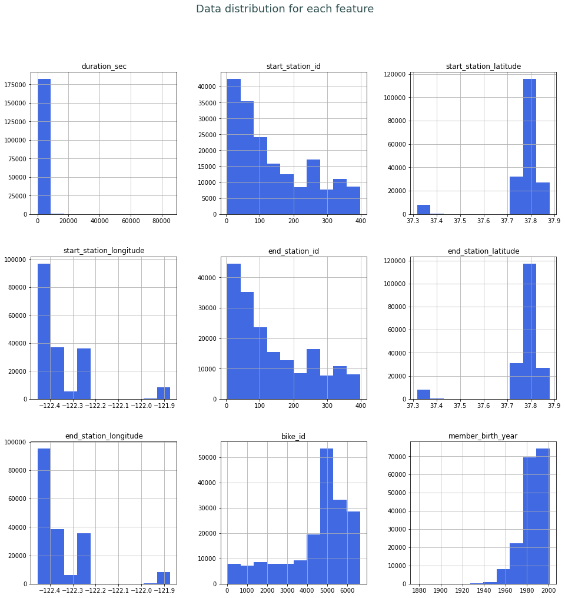

```python
#draw an intial histogram to explore more of our data
df.hist(figsize=(16,16), color="royalblue");
plt.suptitle("Data distribution for each feature", fontsize = 18, color="darkslategrey");
```

## Data Cleaning

```python
# check for duplicates in the dataset
df.duplicated().any()
```

```
False
```

```python
# check for missing values
df.isna().sum()
```

```
duration_sec                  0
start_time                    0
end_time                      0
start_station_id            197
start_station_name          197
start_station_latitude        0
start_station_longitude       0
end_station_id              197
end_station_name            197
end_station_latitude          0
end_station_longitude         0
bike_id                       0
user_type                     0
member_birth_year          8265
member_gender              8265
bike_share_for_all_trip       0
dtype: int64
```

```python
# drop the few missing values from these columns
df.dropna(subset =['start_station_id', 'start_station_name','end_station_id','end_station_name'], inplace=True)
```

```python
df.member_gender.mode()[0]
```

```
'Male'
```

```python
# fill the missing values in the gender column with the mode
df['member_gender'] = df['member_gender'].fillna(df['member_gender'].mode()[0])
```

```python
# fill the missing values in the birth year column
df['member_birth_year'].fillna(method='pad', inplace=True)
```

```python
# check for the changes
df.isna().sum()
```

```
duration_sec               0
start_time                 0
end_time                   0
start_station_id           0
start_station_name         0
start_station_latitude     0
start_station_longitude    0
end_station_id             0
end_station_name           0
end_station_latitude       0
end_station_longitude      0
bike_id                    0
user_type                  0
member_birth_year          0
member_gender              0
bike_share_for_all_trip    0
dtype: int64
```

```python
# drop the useless columns that we won't perform any exploratory analysis on them
df.drop(columns=['start_station_latitude', 'start_station_longitude','end_station_latitude','end_station_longitude'], inplace=True)
```

```python
# convert start and end time dtype to datetime
df["start_time"] = pd.to_datetime(df["start_time"])
df["end_time"] = pd.to_datetime(df["end_time"])
```

The start and end time columns don't convey the day of the trip, so after we converted the dtype to datetime we will create new columns containing the start and end day.

```python
df.insert(5,'start_day', df.start_time.dt.day_name())
df.insert(7,'end_day', df.end_time.dt.day_name())
```

```python
# change the birth year from float to integer
df['member_birth_year'] = df['member_birth_year'].apply(np.int64)
```

```python
def to_str(col_name):
    """This function converts the data type of columns in the dataframe to string
    ------------------------------------
    input:
    ------
   column name in the dataframe

    output:
    ------
    returns the passed column with its new dtype as string (object).
    """
    for column in df.columns:
        col_name = df[column].astype(str)
    return col_name
```

```python
df.start_station_id = to_str(df['start_station_id'])
df.end_station_id = to_str(df['end_station_id'])
df.bike_id = to_str(df['bike_id'])
```

```python
# check for changes
df.dtypes
```

```
duration_sec                        int64
start_time                 datetime64[ns]
end_time                   datetime64[ns]
start_station_id                   object
start_station_name                 object
start_day                          object
end_station_id                     object
end_day                            object
end_station_name                   object
bike_id                            object
user_type                          object
member_birth_year                   int64
member_gender                      object
bike_share_for_all_trip            object
dtype: object
```

To get a better understanding of the duration feature we will convert the duration from seconds to minutes, hours and days and add them to new columns in our dataframe

```python
df.insert(1,'duration_min', df.duration_sec/60)
df.insert(2,'duration_hrs', df.duration_sec/3600)
```

```python
df.insert(3,'duration_days', df.duration_hrs/24)
```

```python
df.head()
```

|  | duration_sec | duration_min | duration_hrs | duration_days | start_time | end_time | start_station_id | start_station_name | start_day | end_station_id | end_day | end_station_name | bike_id | user_type | member_birth_year | member_gender | bike_share_for_all_trip |
| --- | --- | --- | --- | --- | --- | --- | --- | --- | --- | --- | --- | --- | --- | --- | --- | --- | --- |
| 0 | 52185 | 869.750000 | 14.495833 | 0.603993 | 2019-02-28 17:32:10.145 | 2019-03-01 08:01:55.975 | No | Montgomery St BART Station (Market St at 2nd St) | Thursday | No | Friday | Commercial St at Montgomery St | No | Customer | 1984 | Male | No |
| 1 | 42521 | 708.683333 | 11.811389 | 0.492141 | 2019-02-28 18:53:21.789 | 2019-03-01 06:42:03.056 | No | The Embarcadero at Steuart St | Thursday | No | Friday | Berry St at 4th St | No | Customer | 1984 | Male | No |
| 2 | 61854 | 1030.900000 | 17.181667 | 0.715903 | 2019-02-28 12:13:13.218 | 2019-03-01 05:24:08.146 | No | Market St at Dolores St | Thursday | No | Friday | Powell St BART Station (Market St at 4th St) | No | Customer | 1972 | Male | No |
| 3 | 36490 | 608.166667 | 10.136111 | 0.422338 | 2019-02-28 17:54:26.010 | 2019-03-01 04:02:36.842 | No | Grove St at Masonic Ave | Thursday | No | Friday | Central Ave at Fell St | No | Subscriber | 1989 | Other | No |
| 4 | 1585 | 26.416667 | 0.440278 | 0.018345 | 2019-02-28 23:54:18.549 | 2019-03-01 00:20:44.074 | Yes | Frank H Ogawa Plaza | Thursday | Yes | Friday | 10th Ave at E 15th St | Yes | Subscriber | 1974 | Male | Yes |

```python
# calculate summary statistics on the final dataframe
df.describe()
```

|  | duration_sec | duration_min | duration_hrs | duration_days | member_birth_year |
| --- | --- | --- | --- | --- | --- |
| count | 183215.000000 | 183215.000000 | 183215.000000 | 183215.000000 | 183215.000000 |
| mean | 725.902017 | 12.098367 | 0.201639 | 0.008402 | 1984.814589 |
| std | 1795.078654 | 29.917978 | 0.498633 | 0.020776 | 10.113332 |
| min | 61.000000 | 1.016667 | 0.016944 | 0.000706 | 1878.000000 |
| 25% | 325.000000 | 5.416667 | 0.090278 | 0.003762 | 1980.000000 |
| 50% | 514.000000 | 8.566667 | 0.142778 | 0.005949 | 1987.000000 |
| 75% | 796.000000 | 13.266667 | 0.221111 | 0.009213 | 1992.000000 |
| max | 85444.000000 | 1424.066667 | 23.734444 | 0.988935 | 2001.000000 |

```python
df.shape
```

```
(183215, 17)
```

### What is the structure of your dataset?

> This dataset consist of **183215** enteries and **17** columns that present different details for bike rides made in a bike-sharing system.

### What is/are the main feature(s) of interest in your dataset?

> I'd like to know how the trip durations may differ among the other features in this dataset such as, user type, age, gender and also the day of the week, etc.

### What features in the dataset do you think will help support your investigation into your feature(s) of interest?

> Further analysis on the start time, user type, birth year and gender may provide some insights.

## EDA

> **Now we begin with the exploratory analysis after we cleaned our dataframe!**

## Univariate Exploration

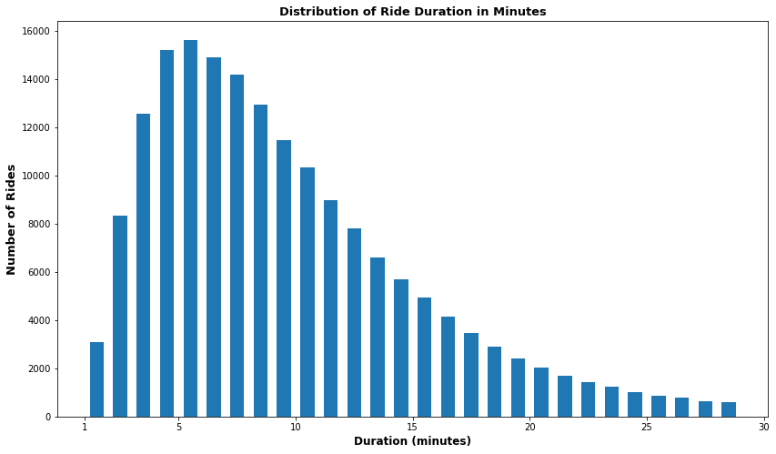

```python
# first, we explore the distribution of duration varible in minutes using histogram
plt.figure(figsize=[14, 8])
bins = np.arange(1, 30, 1)
ticks = [1, 5, 10, 15, 20, 25, 30]
lables= [1, 5, 10, 15, 20, 25, 30]
plt.hist(data=df, x='duration_min',bins=bins, rwidth= 0.6)
plt.title('Distribution of Ride Duration in Minutes', fontweight='bold', fontsize=(13))
plt.xticks(ticks, lables)
plt.xlabel('Duration (minutes)', fontweight='bold', fontsize=(12))
plt.ylabel('Number of Rides', fontweight='bold', fontsize=(13));
```

> The average trip duration is between 3 and 13 minutes.

```python
# which day do bike rides start on the most
df.start_day.value_counts(ascending=True)
```

```
Saturday     15377
Sunday       15503
Monday       26807
Friday       28962
Wednesday    29609
Tuesday      31781
Thursday     35176
Name: start_day, dtype: int64
```

```python
# use reindex to order the week days in their natural order
ordered_days = [ 'Monday', 'Tuesday', 'Wednesday', 'Thursday', 'Friday', 'Saturday', 'Sunday']
df_weekday = df.copy().groupby(df['start_day']).mean(numeric_only=True).reindex(ordered_days)
df_weekday
```

| start_day | duration_sec | duration_min | duration_hrs | duration_days | member_birth_year |
| --- | --- | --- | --- | --- | --- |
| Monday | 713.059201 | 11.884320 | 0.198072 | 0.008253 | 1984.781027 |
| Tuesday | 663.260659 | 11.054344 | 0.184239 | 0.007677 | 1984.546333 |
| Wednesday | 673.740957 | 11.229016 | 0.187150 | 0.007798 | 1984.541930 |
| Thursday | 698.927195 | 11.648787 | 0.194146 | 0.008089 | 1984.494911 |
| Friday | 695.582384 | 11.593040 | 0.193217 | 0.008051 | 1984.519301 |
| Saturday | 901.996098 | 15.033268 | 0.250554 | 0.010440 | 1985.858815 |
| Sunday | 919.329356 | 15.322156 | 0.255369 | 0.010640 | 1986.184545 |

**Recources**: https://stackoverflow.com/questions/47741400/pandas-dataframe-group-and-sort-by-weekday  
https://technology.amis.nl/data-analytics/ordering-rows-in-pandas-data-frame-and-bars-in-plotly-bar-chart-by-day-of-the-week-or-any-other-user-defined-order/

```python
df_weekday['start_day']= df_weekday.index
```

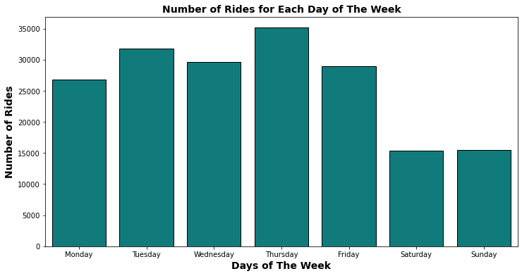

```python
plt.figure(figsize=[12, 6])
sb.countplot(data= df, x='start_day', color="darkcyan", edgecolor="black", order=df_weekday['start_day'])
plt.title('Number of Rides for Each Day of The Week', fontweight='bold', fontsize=(14))
plt.xlabel('Days of The Week', fontweight='bold', fontsize=(14))
plt.ylabel('Number of Rides', fontweight='bold', fontsize=(14));
```

> Most rides seemed to start on **Thursday** for this month of February while **Saturday & Sunday** were the least days of the week bike rides took place on.

```python
# who rides the most, males or females
df['member_gender'].value_counts()
```

```
Male      138763
Female     40805
Other       3647
Name: member_gender, dtype: int64
```

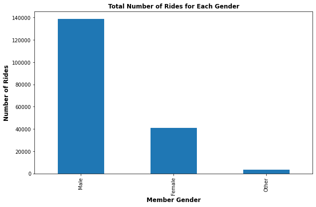

```python
plt.figure(figsize=[10, 6])
df.member_gender.value_counts(ascending=False).plot(kind='bar')
plt.title('Total Number of Rides for Each Gender', fontweight='bold', fontsize=(12))
plt.xlabel('Member Gender', fontweight='bold', fontsize=(12))
plt.ylabel('Number of Rides', fontweight='bold', fontsize=(12));
```

> Males have significantly more bike rides than females.

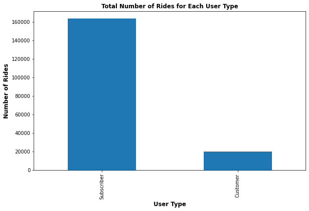

```python
# which user type has the most rides
plt.figure(figsize=[10, 6])
df.user_type.value_counts(ascending=False).plot(kind='bar')
plt.title('Total Number of Rides for Each User Type', fontweight='bold', fontsize=(12))
plt.xlabel('User Type', fontweight='bold', fontsize=(12))
plt.ylabel('Number of Rides', fontweight='bold', fontsize=(12));
```

> Subscribers are significantly more than customers.

### Of the features you investigated, were there any unusual distributions? Did you perform any operations on the data to tidy, adjust, or change the form of the data? If so, why did you do this?

> No, there weren't any unusual distributions for the features I've just investigated. Yes, I had to convert the duration unit from seconds to minutes for easier comprehension and I had to strip the day name from the start time using datetime to show which day with the most bike rides.

## Bivariate Exploration

We want to investigate more about the duration variable and see whether it depends on user type, gender & age or day of the trip, etc.

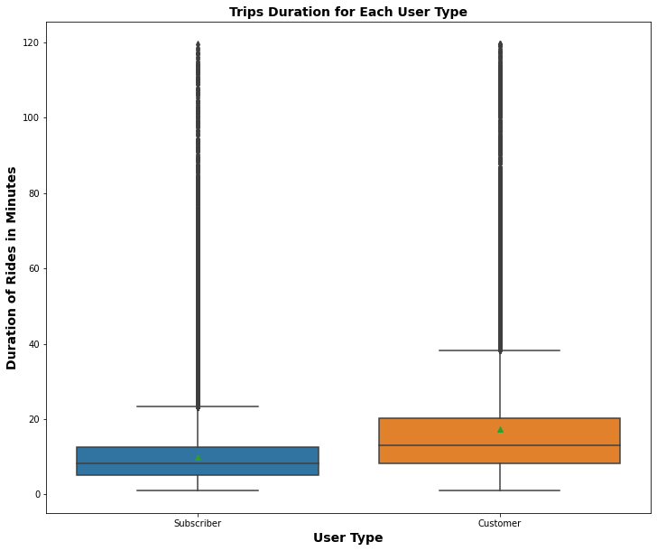

```python
# plot a boxplot between trips duration less than or equals to 120 minutes and user type
plt.figure(figsize=[12, 10])
sb.boxplot(data = df.query('duration_min <= 120'), x = 'user_type', y = 'duration_min', showmeans=True)
plt.title('Trips Duration for Each User Type', fontweight='bold', fontsize=(14))
plt.xlabel('User Type', fontweight='bold', fontsize=(14))
plt.ylabel('Duration of Rides in Minutes', fontweight='bold', fontsize=(14));
```

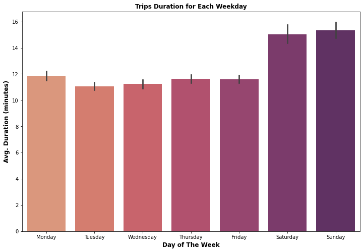

```python
# show the duration for each day
plt.figure(figsize=[12, 8])
sb.barplot(data = df, x = 'start_day', y = 'duration_min', order = df_weekday['start_day'], palette='flare')
plt.title('Trips Duration for Each Weekday', fontweight='bold', fontsize=(12))
plt.xlabel('Day of The Week', fontweight='bold', fontsize=(12))
plt.ylabel('Avg. Duration (minutes)', fontweight='bold', fontsize=(12));
```

> (Weekends) **Sunday** and **Saturday** have the longest duration among the rest weekdays, although they were the least days that have trips as we saw above!

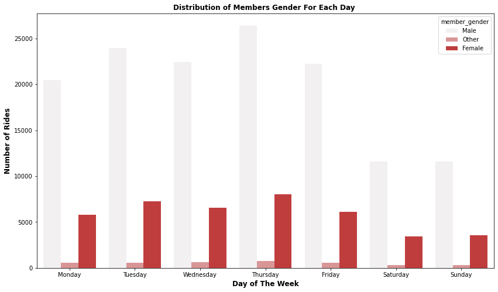

```python
# let`s explore the relation between member gender and day of the week
plt.figure(figsize=[14, 8])
ax = sb.countplot(data = df, x = 'start_day', hue = 'member_gender', order = df_weekday['start_day'], color = "tab:red")
ax.set_title("Distribution of Members Gender For Each Day ",  fontweight='bold', fontsize=(12))
plt.xlabel('Day of The Week',  fontweight='bold', fontsize=(12))
plt.ylabel('Number of Rides', fontweight='bold', fontsize=(12));
ax.legend(title = 'member_gender');
```

Males take signficantly more bike rides than females. This maybe could be because the number of males in this dataset is notably higher than females.

Now, do younger users tend to have longer trip durations?

```python
# substract 2019 from the member birth year to get thier age
df['member_age'] = 2019 - df['member_birth_year']
```

```python
df.head(5)
```

|  | duration_sec | duration_min | duration_hrs | duration_days | start_time | end_time | start_station_id | start_station_name | start_day | end_station_id | end_day | end_station_name | bike_id | user_type | member_birth_year | member_gender | bike_share_for_all_trip | member_age |
| --- | --- | --- | --- | --- | --- | --- | --- | --- | --- | --- | --- | --- | --- | --- | --- | --- | --- | --- |
| 0 | 52185 | 869.750000 | 14.495833 | 0.603993 | 2019-02-28 17:32:10.145 | 2019-03-01 08:01:55.975 | No | Montgomery St BART Station (Market St at 2nd St) | Thursday | No | Friday | Commercial St at Montgomery St | No | Customer | 1984 | Male | No | 35 |
| 1 | 42521 | 708.683333 | 11.811389 | 0.492141 | 2019-02-28 18:53:21.789 | 2019-03-01 06:42:03.056 | No | The Embarcadero at Steuart St | Thursday | No | Friday | Berry St at 4th St | No | Customer | 1984 | Male | No | 35 |
| 2 | 61854 | 1030.900000 | 17.181667 | 0.715903 | 2019-02-28 12:13:13.218 | 2019-03-01 05:24:08.146 | No | Market St at Dolores St | Thursday | No | Friday | Powell St BART Station (Market St at 4th St) | No | Customer | 1972 | Male | No | 47 |
| 3 | 36490 | 608.166667 | 10.136111 | 0.422338 | 2019-02-28 17:54:26.010 | 2019-03-01 04:02:36.842 | No | Grove St at Masonic Ave | Thursday | No | Friday | Central Ave at Fell St | No | Subscriber | 1989 | Other | No | 30 |
| 4 | 1585 | 26.416667 | 0.440278 | 0.018345 | 2019-02-28 23:54:18.549 | 2019-03-01 00:20:44.074 | Yes | Frank H Ogawa Plaza | Thursday | Yes | Friday | 10th Ave at E 15th St | Yes | Subscriber | 1974 | Male | Yes | 45 |

```python
# show summary statistics for the age column
df.member_age.describe()
```

```
count    183215.000000
mean         34.185411
std          10.113332
min          18.000000
25%          27.000000
50%          32.000000
75%          39.000000
max         141.000000
Name: member_age, dtype: float64
```

141 year old bike rider! That's quite odd and probably an outlier that should be removed.

```python
# sort the unique values of member age
np.sort(df.member_age.unique())
```

```
array([ 18,  19,  20,  21,  22,  23,  24,  25,  26,  27,  28,  29,  30,
        31,  32,  33,  34,  35,  36,  37,  38,  39,  40,  41,  42,  43,
        44,  45,  46,  47,  48,  49,  50,  51,  52,  53,  54,  55,  56,
        57,  58,  59,  60,  61,  62,  63,  64,  65,  66,  67,  68,  69,
        70,  71,  72,  73,  74,  75,  76,  77,  78,  80,  81,  85,  86,
        88,  89,  91,  92,  99, 109, 117, 118, 119, 141], dtype=int64)
```

```python
# let's just stick with users younger than 90 years old for more accurate analysis
df = df[df['member_age'] <= 90]
```

```python
# load the final dataframe into csv
df.to_csv('clean_2019_GoBike.csv')
```

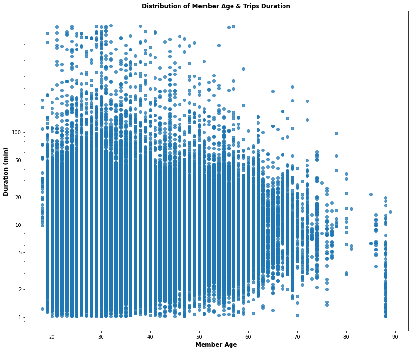

```python
plt.figure(figsize = [14, 12]);
plt.scatter(data = df, x = 'member_age', y = 'duration_min', alpha=0.75)
plt.xlabel('Member Age', fontweight='bold', fontsize=(12))
plt.yscale('log')
plt.yticks([1, 2, 5, 10, 20, 50, 100], [1, 2, 5, 10, 20, 50, 100])
plt.title('Distribution of Member Age & Trips Duration', fontweight='bold', fontsize=(12))
plt.ylabel('Duration (min)', fontweight='bold', fontsize=(12));
```

I'm impressed of the trip duration some senior members can achieve, but indeed more younger members achieve longer trip durations than members older than **60** years old. Under 60 years old the data is evenly distributed.

### Talk about some of the relationships you observed in this part of the investigation. How did the feature(s) of interest vary with other features in the dataset?

> Actually, The duration of the bike ride seems to depend on different factors like the day of the week **(weekends tend to have longer durations)** and the age of the member **(younger members tend to achieve more longer durations)** .

### Did you observe any interesting relationships between the other features (not the main feature(s) of interest)?

> So far, no.

## Multivariate Exploration

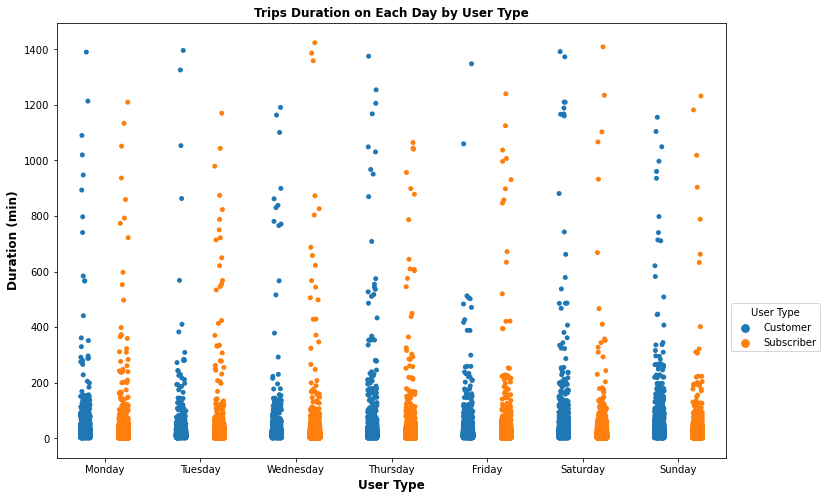

```python
# show the distribution of trip duration according to user type on each day
plt.figure(figsize = [12, 8]);
sb.stripplot(data = df, x = 'start_day', y = 'duration_min', hue='user_type', order = df_weekday['start_day'], jitter=True, dodge=True)
plt.legend(loc='center left', bbox_to_anchor=(1, 0.3), title='User Type')
plt.xlabel('User Type', fontweight='bold', fontsize=(12))
plt.title('Trips Duration on Each Day by User Type', fontweight='bold', fontsize=(12))
plt.ylabel('Duration (min)', fontweight='bold', fontsize=(12));
```

**Resource for the last cell**: https://stackoverflow.com/questions/44413020/how-to-specify-legend-position-in-matplotlib-in-graph-coordinates

### Talk about some of the relationships you observed in this part of the investigation. Were there features that strengthened each other in terms of looking at your feature(s) of interest?

> There wasn't any particular feature on its own but the dataset itself is quite connected together and the main feature of interset (ride duration) depends on different variables as we saw earlier. This dataset could be more thoroughly investigated for sure.

> Finally, along with my analysis, I created a profile report with a quick data analysis using Pandas Profiling Package to explore possible trends among other features I might have missed.

```python
profile = ProfileReport(df, title="Pandas Profiling Report For a Quick Analysis", html={'style':{'full_width':True}})
profile.to_notebook_iframe()
```

[interactive chart not shown]

**Resources**: https://pandas-profiling.github.io/pandas-profiling/docs/master/index.html